# Bikeshare Analysis

The purpose of this document is to analyze the populatity of bikes to predict when bikes are likely used and when they are not.

### Load Packages

The following packages are used:

tidyverse- Mutate Data

lubridate- Minipulate Dates

reshape2- stack data

```r
library(tidyverse)
library(reshape2)
library(lubridate)
library(janitor)
library(here)
```

### Load Data

The selected data is Bikeshare data from Washington D.C. during September 2021. The data is pulled from the capital bikeshare website at https://www.capitalbikeshare.com/system-data.

```r
df1 <- read_csv(here("data","202109-capitalbikeshare-tripdata.csv"))%>%
  clean_names
```

### Filter for first Date

Doing analysis for the first date only, the data is filtered to just events that occurred on September first.

```r
df2<- filter(df1,day(started_at)==1, day(ended_at)==1)
```

### Mutate data to get continous sum

Next, the data must mutated into a data frame which contains a continous count of bikes being ridden at a specif time during the day

```r
df2 <- select(df2, ride_id,started_at,ended_at ) %>%
#df2 <- melt(df2,id.var = c('ride_id'),variable.name="ride")
 pivot_longer(cols= started_at:ended_at,names_to = "ride", values_to = "value") %>%
 mutate(counter= case_when
              (ride =="ended_at" ~ -1, ride== "started_at"~1)) %>%
  arrange(value)%>%
   mutate(bikes_out = cumsum(counter))
```

### Graph data

A visualization of the bikes ridden on the first day of the month is shown below

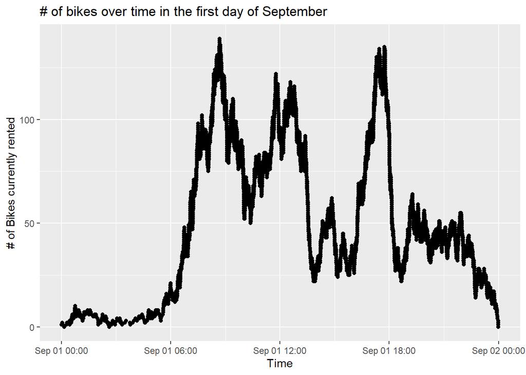

```r
ggplot(data=df2, aes(x=value, y=bikes_out)) +
    geom_point(colour="black", stat="identity")+xlab("Time")+ ylab("# of Bikes currently rented")+labs(title = "# of bikes over time in the first day of September")
```

### in class exercise

```r
df4= df1 %>%
  select(rideable_type,start=started_at,end=ended_at)%>%
  pivot_longer(cols=start:end,names_to="type",values_to="time")%>%
  arrange(time)%>%
  mutate(inc=case_when(
    type == "start" ~ 1,
    type == "end" ~ -1
  ))%>%
  mutate(riders= cumsum(inc))
```

can we plot over the entire month

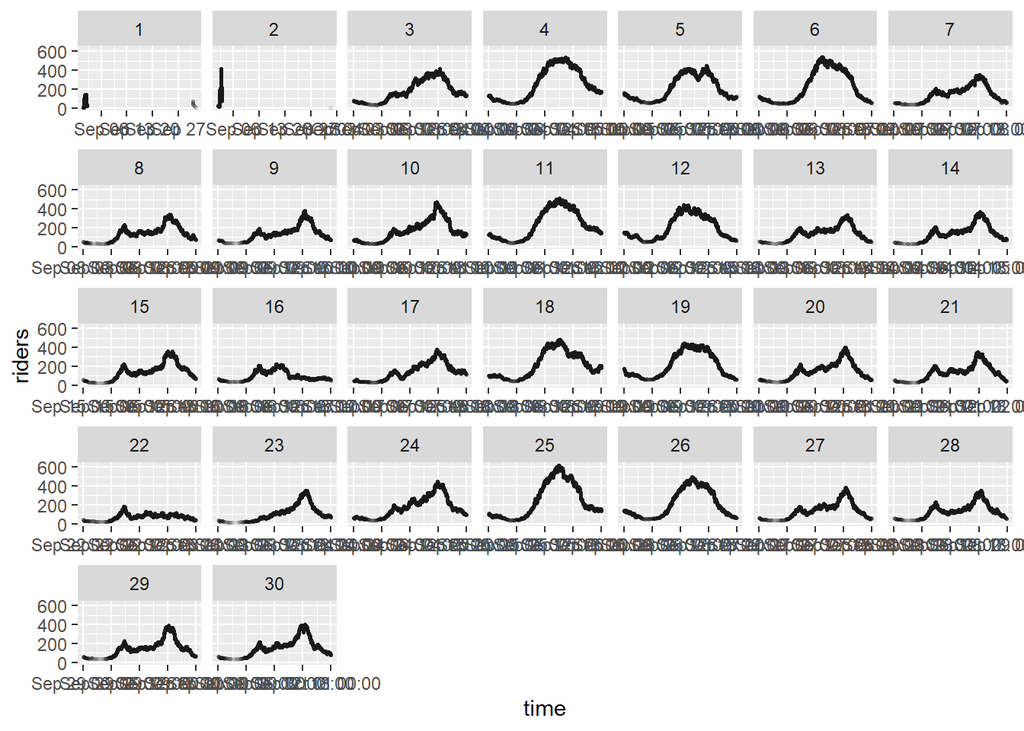

```r
df4 %>%
  mutate(day=day(time))%>%
  ggplot(aes(time,riders))+geom_point(size=.5, alpha=.02)+facet_wrap(~day,ncol=7, scales="free_x")
```

Reflection: This document allowed me to practice not only graphing but additionally some dplyr functions. More importantly, it allowed me to review more difficult functions such as pivot longer. In the visualizations, I was able to practice working with facets.